# Control Structure

Ryan Farhab

2022-09-05

This is the R markdown (rmd) exercise file that accompanies the lecture notes. It will be your sandbox! Fill in the R code chunks, experiment, and have fun!

# Decision Making

### Decision Making

Readings:

https://www.tutorialspoint.com/r/r_decision_making.htm

https://www.datamentor.io/r-programming/if-else-statement

### if statement

Implement and test the code in the slide:

```r
price <- runif(1, min = 10, max = 20)
price
```

```
## [1] 11.48832
```

```r
if (price >=15) {
  print("Buy!")
}
```

### Flowchart of if…else statement

### if…else statement

Implement and test the code in the slide:

```r
price <- runif(1, min = 10, max = 20)
price
```

```
## [1] 15.95929
```

```r
if (price >=15) {
  print("Buy!")
} else {
  print("Sell!")
}
```

```
## [1] "Buy!"
```

### The if…else if…else Statement

### Example

Implement and test the code in the slide:

```r
price <- runif(1, min = 10, max = 20)
price
```

```
## [1] 10.56818
```

```r
if (price >=18) {
  print("Buy!")
} else if (price >=14) {
  print("Hold!")
} else {
  print("Sell!")
}
```

```
## [1] "Sell!"
```

### ifelse()

Readings:

https://www.datamentor.io/r-programming/ifelse-function

*Spreadsheet*: The ifelse() function in R works similar to MS Excel IF function.

### Using ifelse() on a vector

Implement a nested ifelse so that “Buy” if the stock price greater than 16, “Sell” if the price less than 13, and “Hold” otherwise:

```r
price <- runif(5, min = 10, max = 20)
price
```

```
## [1] 16.71463 17.85130 19.36390 19.41929 11.81847
```

```r
ifelse(price >16, "Buy",
       ifelse(price <13, "Sell", "Hold"))
```

```
## [1] "Buy"  "Buy"  "Buy"  "Buy"  "Sell"
```

# Loops

### Loops

Readings:

https://www.tutorialspoint.com/r/r_loops.htm

https://www.datamentor.io/r-programming/for-loop

### Flowchart of for loop

### for loop

Readings:

https://www.tutorialspoint.com/r/r_for_loop.htm

### For Loop Example: Random Walk

```r
p <- rep(0, 100)
p[1] <- 100

for (i in 1:99) {
  p[i+1] <- p[i] + rnorm(1)
}
```

*spreadsheet*: How would you implement this random walk using a spreadsheet?

### Plot the random walk

Plot the random walk you have generated:

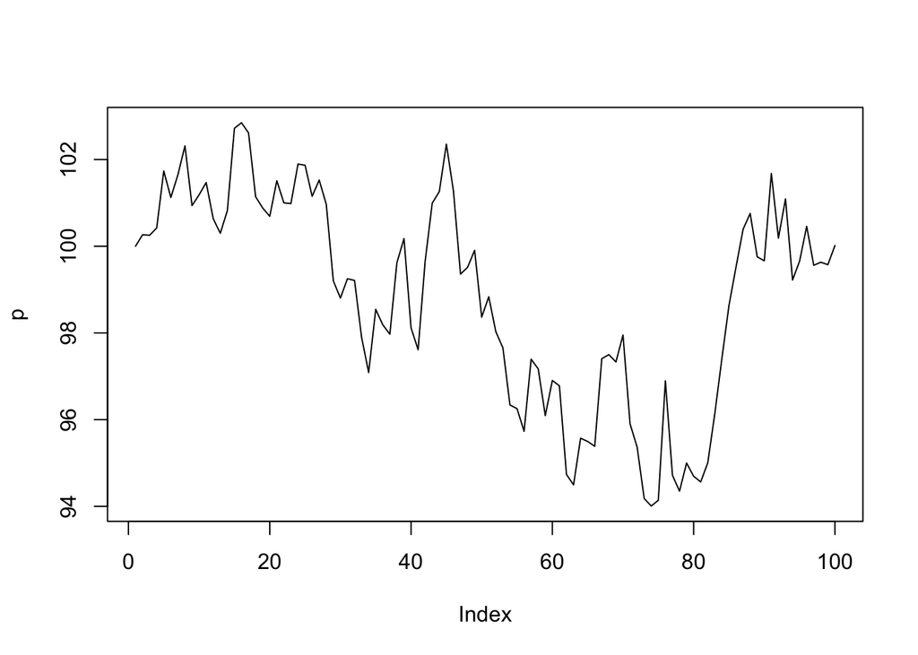

```r
plot(p, type = "l")
```

### Repeat Loop

Readings:

https://www.datamentor.io/r-programming/repeat-loop

### Repeat Loop

### Repeat Loop Example

Use repeat loop to simulate a random walk, with upper bound and lower bound set to end the simulation:

```r
p <- numeric()
p[1] <- 100

i <- 1
repeat{
  p[i+1] <- p[i] + rnorm(1)
  if(p[i+1]>105 | p[i+1]<95) {
    break
  }
  i <- i+1
}
```

### Plot the Random Walk

Plot the random walk you generated with repeat loop:

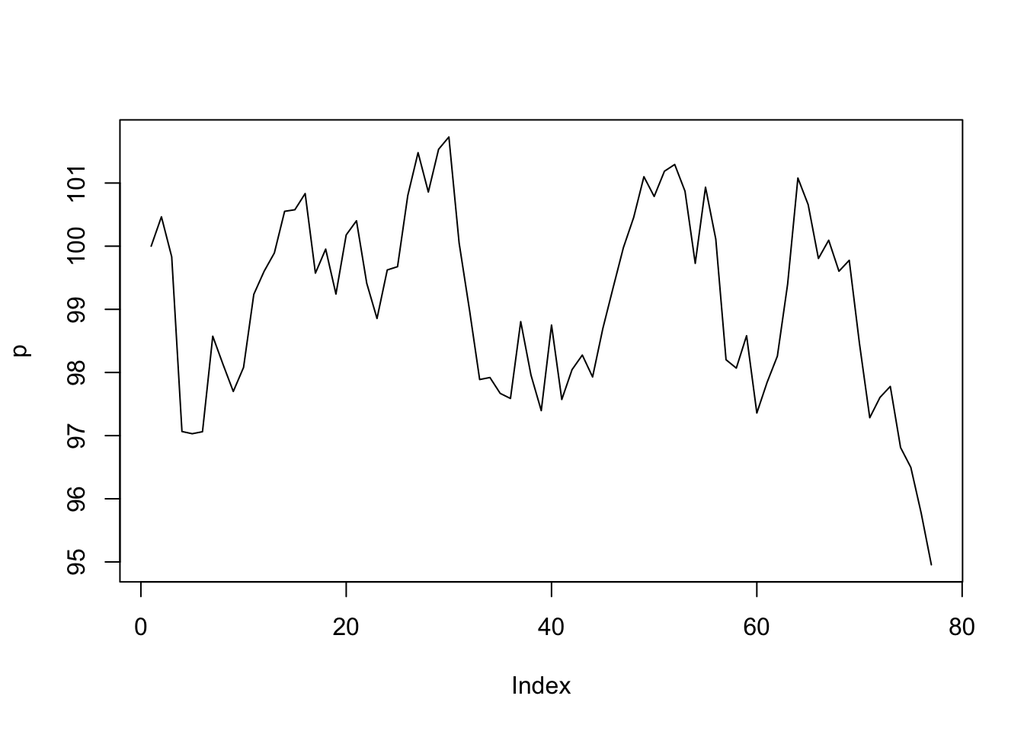

```r
plot(p, type = "l")
```

### While Loop

Readings:

https://www.datamentor.io/r-programming/while-loop

### Syntax of while loop

### While Loop Example

Use while loop to simulate a random walk, with upper bound and lower bound set to end the simulation:

```r
p <- numeric()
p[1] <- 100

i <- 1

while (p[i]<=105 & p[i]>=95) {
  p[i+1] <- p[i] + rnorm(1)
  i <- i+1
}
```

### Plot the Random Walk

Plot the random walk you generated with while loop:

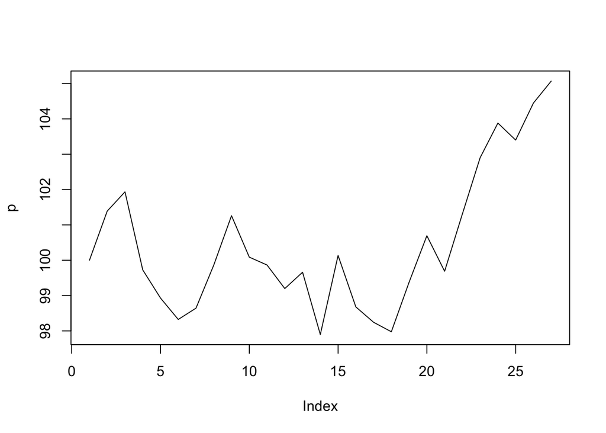

```r
plot(p, type = "l")
```

# Functions

### User-written Functions

Reference: https://www.statmethods.net/management/userfunctions.html

### Function Example

Define a function that calculates the FV, given PV, r, and t:

```r
find_FV <- function(PV, r, t) {
  FV <- PV * (1+r)^t
  return(FV)
}
find_FV(100, 0.1, 2)
```

```
## [1] 121
```

### Default Argument Value

Modify your FV function to set a default value of the discounting horizon t:

```r
find_FV <- function(PV, r, t = 10) {
  FV <- PV * (1+r)^t
  return(FV)
}
find_FV(100, 0.1)
```

```
## [1] 259.3742
```

# Apply Functions As Alternatives To Loops

### The family of apply() functions

Reading: https://www.datacamp.com/community/tutorials/r-tutorial-apply-family

### How To Use apply() in R

### apply() example

Generate a matrix, and use apply() to calculate the sum of each column:

```r
(X <- matrix(1:12, nrow = 3, ncol = 4))
```

```
##      [,1] [,2] [,3] [,4]
## [1,]    1    4    7   10
## [2,]    2    5    8   11
## [3,]    3    6    9   12
```

```r
apply(X, 2, sum)
```

```
## [1]  6 15 24 33
```

Can you calculate the average of each row of your matrix?

```r
apply(X, 1, mean)
```

```
## [1] 5.5 6.5 7.5
```

### The lapply() Function

Reading:

https://www.r-bloggers.com/apply-lapply-rapply-sapply-functions-in-r/

### lapply() example

Create a list and use lapply() to apply some operation on each element of the list:

```r
l <- list(a=1:10, b=11:20)
lapply(l, mean)
```

```
## $a
## [1] 5.5
##
## $b
## [1] 15.5
```

```r
class(lapply(l, mean))
```

```
## [1] "list"
```

### sapply()

Use sapply() to perform the same operation on your list:

```r
sapply(l, mean)
```

```
##    a    b
##  5.5 15.5
```

```r
class(sapply(l, mean))
```

```
## [1] "numeric"
```

Do you notice any difference?

#lapply returns the output in a list format whereas sapply returns the output in a vector or matrix format.

### tapply()

Find out on your own how tapply() works.